# Part I - (Ford GoBike System Data)

## Introduction

> Ford GoBike System Data: This data set includes information about individual rides made in a bike-sharing system covering the greater San Francisco Bay area.

## Preliminary Wrangling

```python
# import all packages and set plots to be embedded inline
import numpy as np
import pandas as pd
import matplotlib.pyplot as plt
import seaborn as sb

%matplotlib inline
```

```python
# Load dataset
df=pd.read_csv('201902-fordgobike-tripdata.csv')
```

```python
df.head()
```

|  | duration_sec | start_time | end_time | start_station_id | start_station_name | start_station_latitude | start_station_longitude | end_station_id | end_station_name | end_station_latitude | end_station_longitude | bike_id | user_type | member_birth_year | member_gender | bike_share_for_all_trip |
| --- | --- | --- | --- | --- | --- | --- | --- | --- | --- | --- | --- | --- | --- | --- | --- | --- |
| 0 | 52185 | 2019-02-28 17:32:10.1450 | 2019-03-01 08:01:55.9750 | 21.0 | Montgomery St BART Station (Market St at 2nd St) | 37.789625 | -122.400811 | 13.0 | Commercial St at Montgomery St | 37.794231 | -122.402923 | 4902 | Customer | 1984.0 | Male | No |
| 1 | 42521 | 2019-02-28 18:53:21.7890 | 2019-03-01 06:42:03.0560 | 23.0 | The Embarcadero at Steuart St | 37.791464 | -122.391034 | 81.0 | Berry St at 4th St | 37.775880 | -122.393170 | 2535 | Customer | NaN | NaN | No |
| 2 | 61854 | 2019-02-28 12:13:13.2180 | 2019-03-01 05:24:08.1460 | 86.0 | Market St at Dolores St | 37.769305 | -122.426826 | 3.0 | Powell St BART Station (Market St at 4th St) | 37.786375 | -122.404904 | 5905 | Customer | 1972.0 | Male | No |
| 3 | 36490 | 2019-02-28 17:54:26.0100 | 2019-03-01 04:02:36.8420 | 375.0 | Grove St at Masonic Ave | 37.774836 | -122.446546 | 70.0 | Central Ave at Fell St | 37.773311 | -122.444293 | 6638 | Subscriber | 1989.0 | Other | No |
| 4 | 1585 | 2019-02-28 23:54:18.5490 | 2019-03-01 00:20:44.0740 | 7.0 | Frank H Ogawa Plaza | 37.804562 | -122.271738 | 222.0 | 10th Ave at E 15th St | 37.792714 | -122.248780 | 4898 | Subscriber | 1974.0 | Male | Yes |

```python
df.shape
```

```
(183412, 16)
```

```python
df.info()
```

```
<class 'pandas.core.frame.DataFrame'>
RangeIndex: 183412 entries, 0 to 183411
Data columns (total 16 columns):
 #   Column                   Non-Null Count   Dtype
---  ------                   --------------   -----
 0   duration_sec             183412 non-null  int64
 1   start_time               183412 non-null  object
 2   end_time                 183412 non-null  object
 3   start_station_id         183215 non-null  float64
 4   start_station_name       183215 non-null  object
 5   start_station_latitude   183412 non-null  float64
 6   start_station_longitude  183412 non-null  float64
 7   end_station_id           183215 non-null  float64
 8   end_station_name         183215 non-null  object
 9   end_station_latitude     183412 non-null  float64
 10  end_station_longitude    183412 non-null  float64
 11  bike_id                  183412 non-null  int64
 12  user_type                183412 non-null  object
 13  member_birth_year        175147 non-null  float64
 14  member_gender            175147 non-null  object
 15  bike_share_for_all_trip  183412 non-null  object
dtypes: float64(7), int64(2), object(7)
memory usage: 22.4+ MB
```

> first, start looking to the dataset,like checking the columns data type, null/missing values and make the changes need also, remove unneed columns based on my observation and importnant points of investigation.

```python
# changing types
df['start_time']=pd.to_datetime(df['start_time'])
df['end_time']=pd.to_datetime(df['end_time'])
```

```python
# check NA for columns start_station_id, end_station_id, member_birth_year
print(sum(df.start_station_id.isna()))
print(sum(df.end_station_id.isna()))
print(sum(df.member_birth_year.isna()))
```

```
197
197
8265
```

```python
# fill na with 0 or columns start_station_id, end_station_id, member_birth_year
df['start_station_id'] = df['start_station_id'].fillna(0)
df['end_station_id'] = df['end_station_id'].fillna(0)
df['member_birth_year'] = df['member_birth_year'].fillna(0)
```

```python
# convert float to integer for columns 'start_station_id','end_station_id','member_birth_year'
intVar=['start_station_id','end_station_id','member_birth_year']
for var in intVar:
    df[var]=df[var].astype(int)
```

```python
# convert objects to categories for columns 'user_type','member_gender','bike_share_for_all_trip'
catVar=['user_type','member_gender','bike_share_for_all_trip']
for var in catVar:
    df[var]=df[var].astype('category')
```

```python
df.describe()
```

|  | duration_sec | start_station_id | start_station_latitude | start_station_longitude | end_station_id | end_station_latitude | end_station_longitude | bike_id | member_birth_year |
| --- | --- | --- | --- | --- | --- | --- | --- | --- | --- |
| count | 183412.000000 | 183412.000000 | 183412.000000 | 183412.000000 | 183412.000000 | 183412.000000 | 183412.000000 | 183412.000000 | 183412.000000 |
| mean | 726.078435 | 138.441569 | 37.771223 | -122.352664 | 136.102780 | 37.771427 | -122.352250 | 4472.906375 | 1895.366132 |
| std | 1794.389780 | 111.811012 | 0.099581 | 0.117097 | 111.544544 | 0.099490 | 0.116673 | 1664.383394 | 411.850439 |
| min | 61.000000 | 0.000000 | 37.317298 | -122.453704 | 0.000000 | 37.317298 | -122.453704 | 11.000000 | 0.000000 |
| 25% | 325.000000 | 47.000000 | 37.770083 | -122.412408 | 44.000000 | 37.770407 | -122.411726 | 3777.000000 | 1979.000000 |
| 50% | 514.000000 | 104.000000 | 37.780760 | -122.398285 | 100.000000 | 37.781010 | -122.398279 | 4958.000000 | 1987.000000 |
| 75% | 796.000000 | 239.000000 | 37.797280 | -122.286533 | 235.000000 | 37.797320 | -122.288045 | 5502.000000 | 1992.000000 |
| max | 85444.000000 | 398.000000 | 37.880222 | -121.874119 | 398.000000 | 37.880222 | -121.874119 | 6645.000000 | 2001.000000 |

```python
# copying dataset to keep clean origenal
df_copy=df.copy()
```

### What is the structure of your dataset?

> features describe the trip information (duration, start_time, end_time) features describe the location of the trip(start_station_id, start_station_name, start_station_latitude start_station_longitude end_station_id, end_station_name, end_station_latitude, end_station_longitude) features about user information (user_type, member_birth_year, member_gender)

> I made some changes for the columns types
> - change the type of start_time, end_time from object to datetime.
> - change the type start_station_id, end_station_id, member_birth_year from float to integer.

### What is/are the main feature(s) of interest in your dataset?

> I'm most interested on figuring out the duration of the trip.

### What features in the dataset do you think will help support your investigation into your feature(s) of interest?

> I think the duration of the trip mostly will affect with the location of the station start/end station, type of the user, age, and the gender.

## Univariate Exploration

> In this section I'll start looking to each column deeper and cleaning the thing that's need, and then find information and visualizing.

> First, I'll start with the duration: 1-Decovering the trip durations 2-Convert the sec into hours and minutes

```python
df_copy['duration_min']=df['duration_sec']/60
df_copy['duration_hours']=df['duration_sec']/3600
```

```python
df_copy.to_csv('duration.csv')
```

```python
df_copy.duration_hours.describe()
```

```
count    183412.000000
mean          0.201688
std           0.498442
min           0.016944
25%           0.090278
50%           0.142778
75%           0.221111
max          23.734444
Name: duration_hours, dtype: float64
```

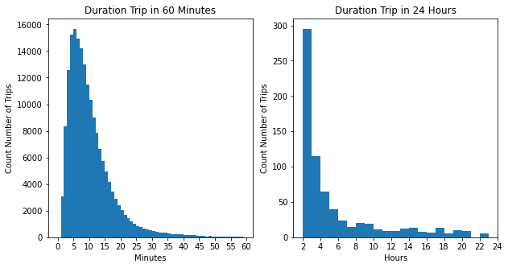

```python
# Set a larger figure size for subplots
plt.figure(figsize=[10, 5])

# histogram on left, for number of the trip duration in 60 minutes
# 1 row, 2 cols, subplot 1
plt.subplot(1, 2, 1)
bins_edge = np.arange(0, 60, 1)
ticks = [0, 5, 10, 15, 20, 25, 30, 35, 40, 45, 50, 55, 60]
labels = ['{}'.format(val) for val in ticks]

plt.hist(data=df_copy, x='duration_min', bins=bins_edge)
plt.title('Duration Trip in 60 Minutes')
plt.xlabel('Minutes')
plt.ylabel('Count Number of Trips')
plt.xticks(ticks, labels)

# histogram on right, for the number of the trip duration in hours
plt.subplot(1, 2, 2)  # 1 row, 2 cols, subplot 2
#plt.figure(figsize=(10,5));
bins_edge=np.arange(2,24,1);
ticks=[2,4,6,8,10,12,14,16,18,20,22,24];
labels=['{}'.format(val) for val in ticks];

plt.hist(data=df_copy, x='duration_hours', bins=bins_edge);
plt.title('Duration Trip in 24 Hours');
plt.xlabel('Hours');
plt.ylabel('Count Number of Trips');
plt.xticks(ticks,labels);
```

```python
# find the mean and median of duration in muntes
print(df_copy.duration_min.mean())
print(df_copy.duration_min.median())
```

```
12.10130725724969
8.566666666666666
```

> Here, I want to see witch the days in month that have more ride counts

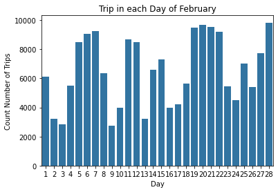

```python
# split the day
df_copy['day'] = df_copy['start_time'].dt.day

base_color = sb.color_palette()[0]

# Use the `color` argument
sb.countplot(data=df_copy, x='day', color=base_color);
plt.title('Trip in each Day of February')
plt.xlabel('Day')
plt.ylabel('Count Number of Trips')
```

This image show us there is a variance on the dayes about number of trips, but it's clear the day 28 Feb is regester the lagrest number of trip and 9 Feb is the lowest.

> Is the ride counts trip affect if the weekday of weekend?

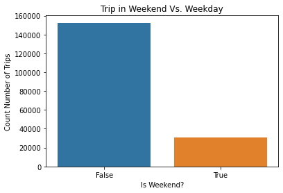

```python
# find the weekday/weekend

# create new coumn to find the name of the day from the date
df_copy["DayOfWeek"] = df_copy["start_time"].dt.weekday

# check if the day weekend or weekday
# the week is starting from monday 0 to friday 5
df_copy["IsWeekend"] = df_copy["DayOfWeek"] >= 5

# visualize the count number of trip in weekend Vs. Weekday
sb.countplot(data=df_copy, x='IsWeekend')

plt.title('Trip in Weekend Vs. Weekday')
plt.xlabel('Is Weekend?')
plt.ylabel('Count Number of Trips')
```

We can see here is the huge difference the bikesharing is most useful at the weekdays than the weekend it might tells us it's used for transportation to the work/school.

> Now, I want to know in witch hour at the day have more ride trip?

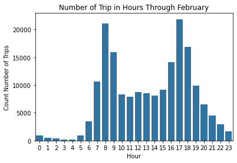

```python
# split the hour
df_copy['hour'] = df_copy['start_time'].dt.hour
base_color = sb.color_palette()[0]

# Use the `color` argument
sb.countplot(data=df_copy, x='hour', color=base_color);
plt.title('Number of Trip in Hours Through February')
plt.xlabel('Hour')
plt.ylabel('Count Number of Trips')
```

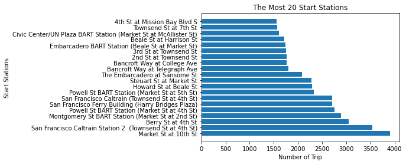

```python
# find top 20 station
top_20 = df_copy['start_station_name'].value_counts()[:20].reset_index()
top_20.columns=['station_name','number_of_trip']


base_color=sb.color_palette()[0]
y = top_20['station_name']
x= top_20['number_of_trip']

plt.barh(y,x)

plt.ylabel('Start Stations')
plt.xlabel('Number of Trip')
plt.title('The Most 20 Start Stations');
```

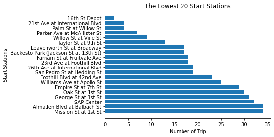

```python
# find lowest 20 station
lowest_20 = df_copy['start_station_name'].value_counts().tail(20).reset_index()
lowest_20.columns=['station_name','number_of_trip']


base_color=sb.color_palette()[0]
y = lowest_20['station_name']
x= lowest_20['number_of_trip']

plt.barh(y,x)

plt.ylabel('Start Stations')
plt.xlabel('Number of Trip')
plt.title('The Lowest 20 Start Stations');
```

From above, these images show us the avegare of the trip in both lagest and lowest trip start station. This might help the desition makers to study to know where should add more customer scrvieses and other needs.

> No.. I want to know the distribution of gender

```python
# first i'll check if there null
print(sum(df_copy.member_gender.isna()))
print(sum(df_copy.member_gender.isnull()))
```

```
8265
8265
```

ok, there is 8265 data with unknown gender

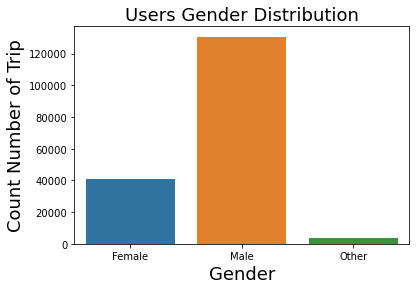

```python
# first i'll check if there null
sum(df_copy.user_type.isna())
sum(df_copy.user_type.isnull())
sb.countplot(data=df_copy, x='member_gender')
plt.xlabel('Gender',size=18)
plt.ylabel('Count Number of Trip',size=18)
plt.title('Users Gender Distribution',size=18);
```

From here we can show male users are represent 3x female

> looking fo the distribution of User Type

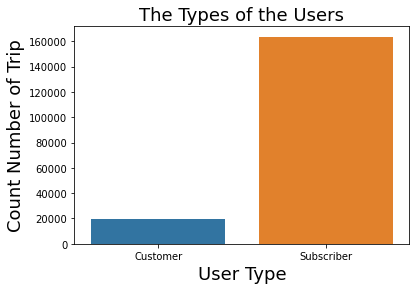

```python
sb.countplot(data=df_copy,x='user_type')
plt.xlabel('User Type',size=18)
plt.ylabel('Count Number of Trip',size=18)
plt.title('The Types of the Users',size=18);
```

From this picture we can show the most users are subscribers.

> And now, i want to know the distribution of the ages of the users

```python
# first, i'll check the member_birth_year column and make the cleaning need

df_copy.member_birth_year.unique()
num_missing=df_copy.query('member_birth_year==0').count()['duration_sec']
num_missing
# ok.. here we know the data is missing 8265 value of birth ear

# create new colum to calcualte the member age
vv = df_copy.query('member_birth_year != 0')

df_copy.loc[df_copy['member_birth_year'] != 0,
            'age'] = df_copy['start_time'].dt.year-vv['member_birth_year']

# describe ages
df_copy.age.describe()
```

```
count    175147.000000
mean         34.193563
std          10.116689
min          18.000000
25%          27.000000
50%          32.000000
75%          39.000000
max         141.000000
Name: age, dtype: float64
```

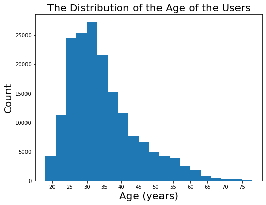

```python
bins=np.arange(18,81,3)
plt.figure(figsize=[8,6])
ax=plt.hist(data=df_copy,x='age',bins=bins)
plt.xticks(np.arange(20,80,5))
plt.xlabel('Age (years)',size=20)
plt.ylabel('Count', size=20)
plt.title('The Distribution of the Age of the Users',size=20);
```

```python
# find number of the elderly >=95
old_ages=df_copy.query('age>=95')
old_ages.count()['duration_sec']
```

```
75
```

From above image we can notice the ages using the bike sharing is from 25 years old to reach the peak at age between 30-35 and decreasing users at 40 years old to reach the minimum while age incresing.

### Discuss the distribution(s) of your variable(s) of interest. Were there any unusual points? Did you need to perform any transformations?

> The distribution of the duratinon varibal is took a large range, so to undrestand the behavoiur of the duration i start studying the duration trips in minutes, and then, studying the duration by hours.

## Bivariate Exploration

> Now let's investigate relationships between pairs of variables in our data.

First, I want to find the reation between the duration and start time

```python
df_copy.head()
```

|  | duration_sec | start_time | end_time | start_station_id | start_station_name | start_station_latitude | start_station_longitude | end_station_id | end_station_name | end_station_latitude | ... | member_birth_year | member_gender | bike_share_for_all_trip | duration_min | duration_hours | day | DayOfWeek | IsWeekend | hour | age |
| --- | --- | --- | --- | --- | --- | --- | --- | --- | --- | --- | --- | --- | --- | --- | --- | --- | --- | --- | --- | --- | --- |
| 0 | 52185 | 2019-02-28 17:32:10.145 | 2019-03-01 08:01:55.975 | 21 | Montgomery St BART Station (Market St at 2nd St) | 37.789625 | -122.400811 | 13 | Commercial St at Montgomery St | 37.794231 | ... | 1984 | Male | No | 869.750000 | 14.495833 | 28 | 3 | False | 17 | 35.0 |
| 1 | 42521 | 2019-02-28 18:53:21.789 | 2019-03-01 06:42:03.056 | 23 | The Embarcadero at Steuart St | 37.791464 | -122.391034 | 81 | Berry St at 4th St | 37.775880 | ... | 0 | NaN | No | 708.683333 | 11.811389 | 28 | 3 | False | 18 | NaN |
| 2 | 61854 | 2019-02-28 12:13:13.218 | 2019-03-01 05:24:08.146 | 86 | Market St at Dolores St | 37.769305 | -122.426826 | 3 | Powell St BART Station (Market St at 4th St) | 37.786375 | ... | 1972 | Male | No | 1030.900000 | 17.181667 | 28 | 3 | False | 12 | 47.0 |
| 3 | 36490 | 2019-02-28 17:54:26.010 | 2019-03-01 04:02:36.842 | 375 | Grove St at Masonic Ave | 37.774836 | -122.446546 | 70 | Central Ave at Fell St | 37.773311 | ... | 1989 | Other | No | 608.166667 | 10.136111 | 28 | 3 | False | 17 | 30.0 |
| 4 | 1585 | 2019-02-28 23:54:18.549 | 2019-03-01 00:20:44.074 | 7 | Frank H Ogawa Plaza | 37.804562 | -122.271738 | 222 | 10th Ave at E 15th St | 37.792714 | ... | 1974 | Male | Yes | 26.416667 | 0.440278 | 28 | 3 | False | 23 | 45.0 |

5 rows × 23 columns

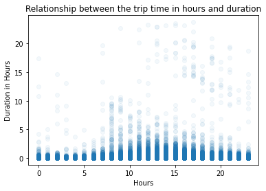

```python
#plt.scatter(data=df_copy, x='hour', y='duration_min')
plt.scatter(data=df_copy, x='hour', y='duration_hours', alpha=1/20)
plt.xlabel('Hours')
plt.ylabel('Duration in Hours');
plt.title('Relationship between the trip time in hours and duration')
```

It's looking there is no relation between the a the time and duration of the trip

> I want to show the relation between the trip duration and user age

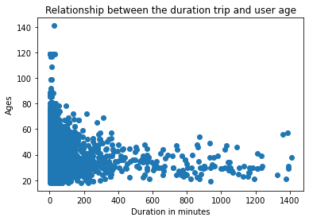

```python
plt.scatter(data=df_copy, x='duration_min', y='age')
plt.xlabel('Duration in minutes')
plt.ylabel('Ages')

plt.title('Relationship between the duration trip and user age')
```

It's clear from the image is there negative correlation between ange and duration of the trip. The trip duration is minimise when the age is old.

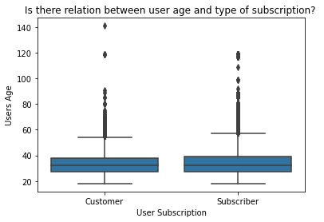

```python
sb.boxplot(data=df_copy,x = "user_type", y = "age", color=base_color)
plt.xlabel('User Subscription')

plt.ylabel('Users Age')

plt.title("Is there relation between user age and type of subscription? ")
```

I think there is week relation, both customer and subsriber ages between 20-60 and the mean also in the same range.

> Relation between trip duration and user type

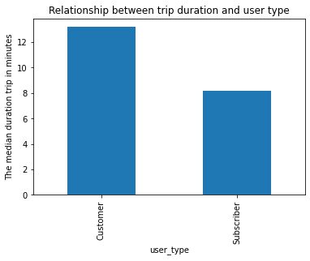

```python
df_copy.groupby('user_type')['duration_min'].median().sort_values(ascending=False).plot(kind='bar')

plt.xlabel('user_type')
plt.ylabel('The median duration trip in minutes')
plt.title("Relationship between trip duration and user type")

plt.show()
```

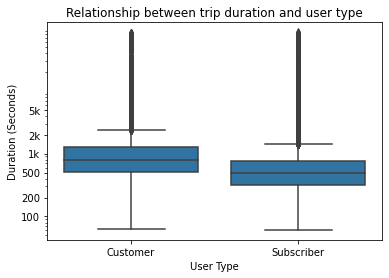

```python
sb.boxplot(data=df_copy,x='user_type',y='duration_sec',color=base_color)
plt.yscale('log')
y_ticklocs=[100,200,500,1e3,2e3,5e3]
y_ticklabels=['100','200','500','1k','2k','5k']
plt.yticks(y_ticklocs,y_ticklabels)
plt.xlabel('User Type')
plt.ylabel('Duration (Seconds)')
plt.title('Relationship between trip duration and user type')
```

from two picture above we can see the customers spend time on trip more than subscriber

> Studying if there relation between gender and duration

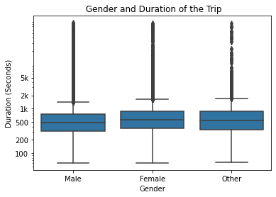

```python
sb.boxplot(data=df_copy,x='member_gender',y='duration_sec',color=base_color,order=['Male','Female','Other'])
plt.yscale('log')
y_ticklocs=[100,200,500,1e3,2e3,5e3]
y_ticklabels=['100','200','500','1k','2k','5k']
plt.yticks(y_ticklocs,y_ticklabels)
plt.xlabel('Gender')
plt.ylabel('Duration (Seconds)')
plt.title(' Gender and Duration of the Trip');
```

From above image we can see the male have shorter trip than others

### Did you observe any interesting relationships between the other features (not the main feature(s) of interest)?

> - the older age user is female

## Multivariate Exploration

> Create plots of three or more variables to investigate your data even

Here, I'll studying the affect of feature age and gender in duration of the trip

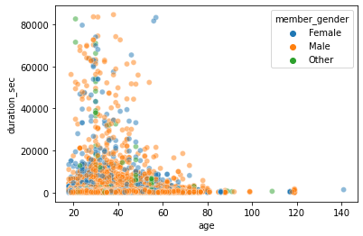

```python
sb.scatterplot(data=df_copy,y='duration_sec',x='age', alpha=0.5, hue='member_gender', legend='full')
```

Under the duration of 20000 and between age 20 and 60 it is clear that both male and are close. However Above 60000 second in the same range of age male have littile more values. But it is clear for both genders above the age of 60 no values above 20000

Here, I'll studying the affect of user type and age and in duration of the trip

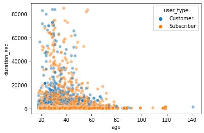

```python
# Age and duration with user type
sb.scatterplot(data=df_copy,y='duration_sec',x='age', alpha=0.5, hue='user_type', legend='full')
```

most of customer and subcribers rides are under 20000 in all ages. However above the age of 70 most riders are subscribers

> No, I'll studing the bike_share_for_all_trip feature with type of user

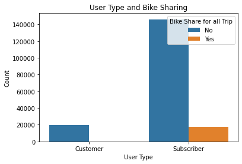

```python
sb.countplot(data=df_copy, x='user_type', hue='bike_share_for_all_trip')
plt.xlabel('User Type')
plt.ylabel('Count')
plt.legend(title='Bike Share for all Trip')
plt.title('User Type and Bike Sharing')
```

Bike sharing occurs only by subscribers which is intuitive.

### Were there any interesting or surprising interactions between features?

> - bike sharing is accure for sbscriber only